# Final Project Pitch

2024-07-31

## Objective of the App.

We use the dataset *iris* from the base R package and extract the columns named *Sepal.Length*, *Sepal.Width* and *Species*.  
For reference the summaries of the three variables are displayed below;

```
##   Sepal.Length    Sepal.Width          Species
##  Min.   :4.300   Min.   :2.000   setosa    :50
##  1st Qu.:5.100   1st Qu.:2.800   versicolor:50
##  Median :5.800   Median :3.000   virginica :50
##  Mean   :5.843   Mean   :3.057
##  3rd Qu.:6.400   3rd Qu.:3.300
##  Max.   :7.900   Max.   :4.400
```

The goal of the app will be to give a prediction of *Sepal.width* given a value of *Sepal.Length* and *Species* using linear regression models by species. The app is equipped with a selection menu allowing to first read the short documentation and then proceed to using the app.

## Configuration of the App

- **Input Side Panel**  
  it contains check boxes to select the species, and an entry box for the value of *Sepal.Length* which will be used for the prediction(s).
- **Output Panel**  
  The output panel has two components:
- The upper part is a plot panel displaying the scatterplot, fitted regressions lines for the selected species (a snapshot, when all the three species are selected is given on the next slide).
- The lower part gives the predicted value(s) of *Sepal.Width* along with the prediction margin of error corresponding to a level .95.

## The graphics on The app.

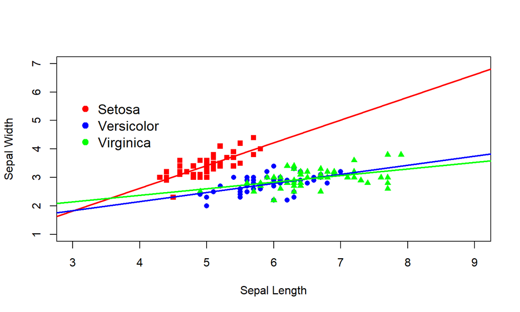

## An example of Computation performed by the App

Assuming that the species is Setosa and the input value for *Sepal.Length* is 5.2,

- The predicted value for *sepal.Width* will be 3.583
- The corresponding margin of error at level .95 will be 0.042